# TelcoCustomerChurn_IT16170094

**1.Importing the libraries**

```python
import numpy as np
import pandas as pd
import matplotlib.pyplot as plt
import seaborn as sns
from pylab import rcParams
%matplotlib inline
```

**2.Loading the dataset**

```python
churn_data = pd.read_csv("C:\\Users\\Himashi\\Desktop\\WA_Fn-UseC_-Telco-Customer-Churn.csv")
churn_data.head()
```

|  | customerID | gender | SeniorCitizen | Partner | Dependents | tenure | PhoneService | MultipleLines | InternetService | OnlineSecurity | ... | DeviceProtection | TechSupport | StreamingTV | StreamingMovies | Contract | PaperlessBilling | PaymentMethod | MonthlyCharges | TotalCharges | Churn |
| --- | --- | --- | --- | --- | --- | --- | --- | --- | --- | --- | --- | --- | --- | --- | --- | --- | --- | --- | --- | --- | --- |
| 0 | 7590-VHVEG | Female | 0 | Yes | No | 1 | No | No phone service | DSL | No | ... | No | No | No | No | Month-to-month | Yes | Electronic check | 29.85 | 29.85 | No |
| 1 | 5575-GNVDE | Male | 0 | No | No | 34 | Yes | No | DSL | Yes | ... | Yes | No | No | No | One year | No | Mailed check | 56.95 | 1889.5 | No |
| 2 | 3668-QPYBK | Male | 0 | No | No | 2 | Yes | No | DSL | Yes | ... | No | No | No | No | Month-to-month | Yes | Mailed check | 53.85 | 108.15 | Yes |
| 3 | 7795-CFOCW | Male | 0 | No | No | 45 | No | No phone service | DSL | Yes | ... | Yes | Yes | No | No | One year | No | Bank transfer (automatic) | 42.30 | 1840.75 | No |
| 4 | 9237-HQITU | Female | 0 | No | No | 2 | Yes | No | Fiber optic | No | ... | No | No | No | No | Month-to-month | Yes | Electronic check | 70.70 | 151.65 | Yes |

5 rows × 21 columns

**3.Exploring the data**

```python
churn_data.shape
```

```
(7043, 21)
```

```python
churn_data.columns.tolist()
```

```
['customerID',
 'gender',
 'SeniorCitizen',
 'Partner',
 'Dependents',
 'tenure',
 'PhoneService',
 'MultipleLines',
 'InternetService',
 'OnlineSecurity',
 'OnlineBackup',
 'DeviceProtection',
 'TechSupport',
 'StreamingTV',
 'StreamingMovies',
 'Contract',
 'PaperlessBilling',
 'PaymentMethod',
 'MonthlyCharges',
 'TotalCharges',
 'Churn']
```

```python
churn_data.dtypes
```

```
customerID           object
gender               object
SeniorCitizen         int64
Partner              object
Dependents           object
tenure                int64
PhoneService         object
MultipleLines        object
InternetService      object
OnlineSecurity       object
OnlineBackup         object
DeviceProtection     object
TechSupport          object
StreamingTV          object
StreamingMovies      object
Contract             object
PaperlessBilling     object
PaymentMethod        object
MonthlyCharges      float64
TotalCharges         object
Churn                object
dtype: object
```

```python
churn_data.info()
```

```
<class 'pandas.core.frame.DataFrame'>
RangeIndex: 7043 entries, 0 to 7042
Data columns (total 21 columns):
customerID          7043 non-null object
gender              7043 non-null object
SeniorCitizen       7043 non-null int64
Partner             7043 non-null object
Dependents          7043 non-null object
tenure              7043 non-null int64
PhoneService        7043 non-null object
MultipleLines       7043 non-null object
InternetService     7043 non-null object
OnlineSecurity      7043 non-null object
OnlineBackup        7043 non-null object
DeviceProtection    7043 non-null object
TechSupport         7043 non-null object
StreamingTV         7043 non-null object
StreamingMovies     7043 non-null object
Contract            7043 non-null object
PaperlessBilling    7043 non-null object
PaymentMethod       7043 non-null object
MonthlyCharges      7043 non-null float64
TotalCharges        7043 non-null object
Churn               7043 non-null object
dtypes: float64(1), int64(2), object(18)
memory usage: 1.1+ MB
```

**4.Reviewing the distribution of the target feature : Churn**

```python
churn_data['Churn'].value_counts(sort = False)
```

```
No     5174
Yes    1869
Name: Churn, dtype: int64
```

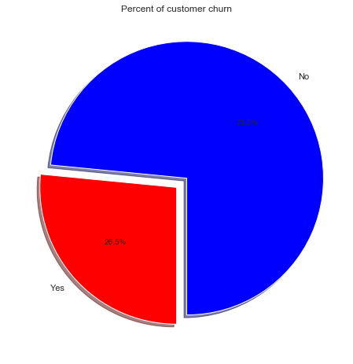

```python
labels =churn_data['Churn'].value_counts(sort = True).index
sizes = churn_data['Churn'].value_counts(sort = True)
colors = ["blue","red"]
explode = (0.1,0)
rcParams['figure.figsize'] = 8,8
plt.pie(sizes, explode=explode, labels=labels, colors=colors, autopct='%1.1f%%', shadow=True, startangle=270,)
plt.title('Percent of customer churn')
plt.show()
```

Observations : In the dataset, percentage of churned customers is 26.5%. The target seems slightly unbalanced.

**5.Manipulating the data**

5.1.Converting the TotalCharges column from object type to numeric type

```python
churn_data['TotalCharges'] = pd.to_numeric(churn_data.TotalCharges, errors='coerce')
```

5.2.Converting the SeniorCitizen column from numeric type to object type

```python
churn_data["SeniorCitizen"] = churn_data["SeniorCitizen"].replace({1:"Yes",0:"No"})
#Re-check to verify changes
churn_data.info()
```

```
<class 'pandas.core.frame.DataFrame'>
RangeIndex: 7043 entries, 0 to 7042
Data columns (total 21 columns):
customerID          7043 non-null object
gender              7043 non-null object
SeniorCitizen       7043 non-null object
Partner             7043 non-null object
Dependents          7043 non-null object
tenure              7043 non-null int64
PhoneService        7043 non-null object
MultipleLines       7043 non-null object
InternetService     7043 non-null object
OnlineSecurity      7043 non-null object
OnlineBackup        7043 non-null object
DeviceProtection    7043 non-null object
TechSupport         7043 non-null object
StreamingTV         7043 non-null object
StreamingMovies     7043 non-null object
Contract            7043 non-null object
PaperlessBilling    7043 non-null object
PaymentMethod       7043 non-null object
MonthlyCharges      7043 non-null float64
TotalCharges        7032 non-null float64
Churn               7043 non-null object
dtypes: float64(2), int64(1), object(18)
memory usage: 1.1+ MB
```

```python
churn_data.describe()
```

|  | tenure | MonthlyCharges | TotalCharges |
| --- | --- | --- | --- |
| count | 7043.000000 | 7043.000000 | 7032.000000 |
| mean | 32.371149 | 64.761692 | 2283.300441 |
| std | 24.559481 | 30.090047 | 2266.771362 |
| min | 0.000000 | 18.250000 | 18.800000 |
| 25% | 9.000000 | 35.500000 | 401.450000 |
| 50% | 29.000000 | 70.350000 | 1397.475000 |
| 75% | 55.000000 | 89.850000 | 3794.737500 |
| max | 72.000000 | 118.750000 | 8684.800000 |

5.3.Checking for missing values

```python
churn_data.isnull().sum()
```

```
customerID           0
gender               0
SeniorCitizen        0
Partner              0
Dependents           0
tenure               0
PhoneService         0
MultipleLines        0
InternetService      0
OnlineSecurity       0
OnlineBackup         0
DeviceProtection     0
TechSupport          0
StreamingTV          0
StreamingMovies      0
Contract             0
PaperlessBilling     0
PaymentMethod        0
MonthlyCharges       0
TotalCharges        11
Churn                0
dtype: int64
```

5.4.Dropping missing values

```python
churn_data.dropna(inplace = True)
#Re-check for missing values
churn_data.isnull().sum()
```

```
customerID          0
gender              0
SeniorCitizen       0
Partner             0
Dependents          0
tenure              0
PhoneService        0
MultipleLines       0
InternetService     0
OnlineSecurity      0
OnlineBackup        0
DeviceProtection    0
TechSupport         0
StreamingTV         0
StreamingMovies     0
Contract            0
PaperlessBilling    0
PaymentMethod       0
MonthlyCharges      0
TotalCharges        0
Churn               0
dtype: int64
```

5.5.Dropping customerID column since it is not required for the analysis

```python
churn_data.drop(["customerID"],axis=1,inplace = True)
#Re-check whether "customerID" column has been dropped
churn_data.head()
```

|  | gender | SeniorCitizen | Partner | Dependents | tenure | PhoneService | MultipleLines | InternetService | OnlineSecurity | OnlineBackup | DeviceProtection | TechSupport | StreamingTV | StreamingMovies | Contract | PaperlessBilling | PaymentMethod | MonthlyCharges | TotalCharges | Churn |
| --- | --- | --- | --- | --- | --- | --- | --- | --- | --- | --- | --- | --- | --- | --- | --- | --- | --- | --- | --- | --- |
| 0 | Female | No | Yes | No | 1 | No | No phone service | DSL | No | Yes | No | No | No | No | Month-to-month | Yes | Electronic check | 29.85 | 29.85 | No |
| 1 | Male | No | No | No | 34 | Yes | No | DSL | Yes | No | Yes | No | No | No | One year | No | Mailed check | 56.95 | 1889.50 | No |
| 2 | Male | No | No | No | 2 | Yes | No | DSL | Yes | Yes | No | No | No | No | Month-to-month | Yes | Mailed check | 53.85 | 108.15 | Yes |
| 3 | Male | No | No | No | 45 | No | No phone service | DSL | Yes | No | Yes | Yes | No | No | One year | No | Bank transfer (automatic) | 42.30 | 1840.75 | No |
| 4 | Female | No | No | No | 2 | Yes | No | Fiber optic | No | No | No | No | No | No | Month-to-month | Yes | Electronic check | 70.70 | 151.65 | Yes |

**6.Reviewing the distribution of categorical features**

This dataset has 16 categorical features including 6 binary (Yes/No) features, 9 features with three unique values each and 1 feature with four unique values

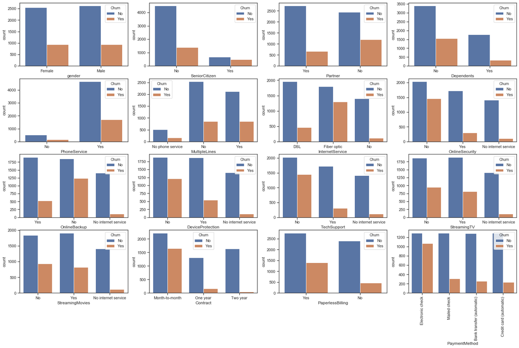

```python
sns.set(style="ticks", color_codes=True)

fig, axes = plt.subplots(nrows = 4,ncols = 4,figsize = (25,15))
sns.countplot(x = "gender", data = churn_data, hue = churn_data.Churn, ax=axes[0][0])
sns.countplot(x = "SeniorCitizen", data = churn_data, hue = churn_data.Churn, ax=axes[0][1])
sns.countplot(x = "Partner", data = churn_data, hue = churn_data.Churn, ax=axes[0][2])
sns.countplot(x = "Dependents", data = churn_data, hue = churn_data.Churn, ax=axes[0][3])
sns.countplot(x = "PhoneService", data = churn_data, hue = churn_data.Churn, ax=axes[1][0])
sns.countplot(x = "MultipleLines", data = churn_data, hue = churn_data.Churn, ax=axes[1][1])
sns.countplot(x = "InternetService", data = churn_data, hue = churn_data.Churn, ax=axes[1][2])
sns.countplot(x = "OnlineSecurity", data = churn_data, hue = churn_data.Churn, ax=axes[1][3])
sns.countplot(x = "OnlineBackup", data = churn_data, hue = churn_data.Churn, ax=axes[2][0])
sns.countplot(x = "DeviceProtection", data = churn_data, hue = churn_data.Churn, ax=axes[2][1])
sns.countplot(x = "TechSupport", data = churn_data, hue = churn_data.Churn, ax=axes[2][2])
sns.countplot(x = "StreamingTV", data = churn_data, hue = churn_data.Churn, ax=axes[2][3])
sns.countplot(x = "StreamingMovies", data = churn_data, hue = churn_data.Churn, ax=axes[3][0])
sns.countplot(x = "Contract", data = churn_data, hue = churn_data.Churn, ax=axes[3][1])
sns.countplot(x = "PaperlessBilling", data = churn_data, hue = churn_data.Churn, ax=axes[3][2])
ax=sns.countplot(x = "PaymentMethod", data = churn_data, hue = churn_data.Churn, ax=axes[3][3])
ax.set_xticklabels(ax.get_xticklabels(),rotation=90)

plt.show(fig)
```

Observations :

Gender, PhoneService, MultipleLines, and Streaming service don't have clear difference churn rates between the values in categories.

Senior citizens have a much higher churn rate against non-senior customers.

Customers that don’t have partners/dependents are more likely to churn.

Customers without internet have a very low churn rate.

Customers with Fiber optic connections are more probable to churn compared to the customers having a DSL connection.

Customers that don’t use OnlineSecurity, OnlineBackup, DeviceProtection, and TechSupport services are more likely to churn.

Customers that use PaperlessBilling are more prone to churn.

Customers having short term contracts have higher churn rates.

Customers that use the Electronic check Payment method have a high churn rate.

**7.Reviewing the distribution of numerical features**

There are 3 numerical columns: tenure, monthly charges and total charges.

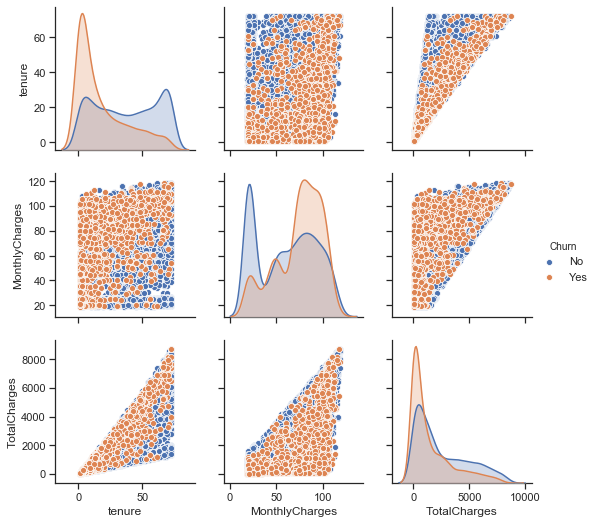

```python
sns.pairplot(churn_data,vars = ['tenure','MonthlyCharges','TotalCharges'], hue="Churn")
```

Observations:

Customers having lower tenure and higher monthly charges tend to churn more.